# Site

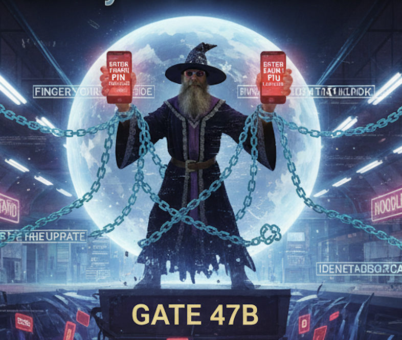

Cover

Stranded by Security in a World That Won’t Listen.

There was a moment, somewhere between Gate 47 B and a flickering fluorescent noodle stand in a foreign airport, that I realized I had been erased. Not mugged. Not robbed. Not even hacked in the traditional sense. I had been secured out of existence. I pressed my thumb to the phone like a trained lab rat. Years of muscle memory and biometric bliss. The phone stared back at me with the emotional warmth of a prison guard. ENTER YOUR PIN TO UNLOCK. Ah yes. The PIN. The ancient rune. The forgotten incantation. The thing I hadn’t typed since the Obama administration. No problem, I thought. I’ve got a backup phone to prevent this kind of situation with an older version of the operating system that has not seen an update for ages. Same message. Same dead stare. Same corporate shrug. Two phones. Zero options. Welcome to the paperless future, pal. The First Rule of the Digital Jungle: You Never Own the Device. Somewhere in California, probably while a product manager was sipping latte and nodding solemnly at a PowerPoint, Google Play Services flipped a switch. A silent switch. No consent. No warning. No “Hey traveler, you might want to sit down for this.” They call it a security re-validation . A 72 hour “biometric expiration.” A tidy little rule buried deep in the Android underbelly that says: Every three days, prove you still remember the master key, or get fucked. The master key, of course, is the PIN. The real key. Fingerprints are just party tricks. Convenience theater. A lie we tell ourselves while the encryption gods sharpen their knives. Both phones were tied to the same mandetory Google account. Same master. Same leash. When the command came down, they locked simultaneously, like synchronized swimmers diving into a concrete pool. I wasn’t unlucky. I was compliant . Financial Paralysis Is a Feature, Not a Bug First thing you notice when you’re digitally erased is how fast money becomes theoretical. I thought I was smart distributing my money across different bank accounts, but no phone means no banking app. No phone means no access to any of my accounts. No banking app means, no hotel, no taxi, and no boarding pass that is also needs to be on the phone for your flight home . I staggered into a bank branch, an actual building with humans inside, and explained the situation. Slowly. Calmly. Desperately and that I need access to my bank account online. They listened. Nodded. Smiled. Then told me to use the self-service terminal . The same terminal that requires… wait for it… a pin. I interrupted them. Five times. Raised my voice that no airline accepts cash at the counter any more. Lowered my expectations. Eventually I realized the truth: the clerks weren’t stupid. They were trained. Programmed to trust the machine more than the bleeding mammal standing in front of them. The system had no checkbox for “Customer has been digitally vaporized by a West Coast update.” So the humans did nothing. As instructed. The No-PC Trap: Or How to Turn Phones Into Bricks. At this point you start thinking reset. Nuclear option. Burn it all down and rebuild. Except, surprise!, modern Samsung security treats a locked phone like stolen plutonium. Want to factory reset? Plug it into a PC. No PC? Too bad. Wall charger doesn’t count. Hotel TV doesn’t count. Airport USB doesn’t count. The phone demands a data-speaking machine, like some jealous god refusing sacrifice unless it’s served on the right altar. So there I was: holding two phones I owned, paid for, protected, updated, and could not unlock, reset, wipe, or repurpose. Not stolen. Not broken. Just… forbidden. Identity, Now Fully Automated Maybe Google can help, I thought. After all, Google is my identity now. Except Google wanted proof that I was me. And the proof had to satisfy an algorithm. Passport photo rejected. Lighting too dark. Try again. Try harder. Try being more photogenic for the machine. There is no judge. No appeal. No human who can say, “Yes, this person exists and is panicking in front of me.” When the AI says no, the universe agrees. And here’s the punchline: after you factory reset (if you somehow find a PC in the jungle), Factory Reset Protection kicks in. “Enter the Google password previously associated with this device.” The same Google account you’re locked out of. The circle is complete. The trap is perfect. The Geopolitical Kill Switch Nobody Wants to Talk About. At some point, probably around hour twelve, you realize this isn’t just a personal horror story. It’s a preview. You don’t need bombs or blackouts to cripple a country anymore or as a matter of fact a whole continent. You just need a policy update. A security refresh. A compliance push. Flip the right switch and millions lose access to money, travel, communication, identity, overnight. We didn’t trade sovereignty for safety. We traded it for convenience . And convenience has a kill switch. Forced Erasure as Customer Support In the end, there is only one solution left: total destruction . Erase eight years of photos. Erase messages. Contacts. History, subscriptions. Erase the digital record of your life, just to use the hardware again. And even then, only if the gods allow it. This is not a glitch. This is the design. A fortress so secure it locks the owner inside and throws away the key. The Zero-Option Reality Trigger: A silent Google update. Cause: Years of biometric complacency. Failure: AI verification with no human override. Trap: No PC, no reset, no mercy. Outcome: Digital erasure in a paperless world. We don’t own our devices. We rent access to ourselves. And the rent can be raised, or revoked, at any time. Zero Options, Full Compliance. This January 17th 2026 was the Day My Phone Decided I Didn’t Exist. Locked Out by Design. Biometrics, Bureaucracy, and the Death of Ownership with Security So Strong It eats you. Welcome to the Paperless Gulag. Encrypted and Erased. The Fingerprint Was a Lie and this is how I lost my identity to a silent update. The Convenience Trap until a machine said No. Digital Sovereignty Is a Myth. Safety Becomes a Weapon. Factory Reset, Factory Forget. A security theater at a Human Cost. Ghosted by Google. Identity as a Subscription Service The Algorithm Doesn’t Care If You’re Real. This Phone Is Not Yours Locked, Loaded, and Legally Powerless. The Kill Switch in Your Pocket. Ownership Ends at the Update it’s the Zero-Option Lockout.